# Project Context

# Section 5

Goal : Find the length of sequences for prime and non prime numbers

```python
#determines if a number is prime
def isPrime(x,y):
    for i in range (2,y):
        #x is divisible by any of 2-9 then it is not a prime number
        if(x %i ==0 and x != i):
            return False
    return True
```

**Define isPrime(x,y)** isPrime(x,y) returns true if x is a prime number, it will check if x is divisible by any number from 2 to y as long as it is divisible by more than 1 number it will return false otherwise it will return true

**Explore 5** \ Explore the length of sequence of numbers that are prime and non prime

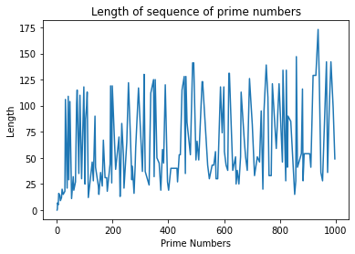

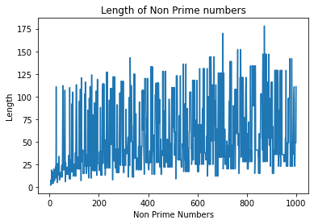

```python
#seperate and graph prime and non-prime numbers
los,lon = getSeq(0,1000)
#Array used to store prime numbers
prime =[]
#Array used to store the prime number sequence lengths
primelen =[]
#Array used to store non prime numbers
nonprime = []
#Array used to store non prime number sequences
nonprimelength = []
for a in range (len(los)):
    #if the number is prime then add it to the prime array
    if(isPrime(lon[a],1000)):
        prime.append(lon[a])
        primelen.append(len(los[a]))
    else:
        #else Add the number to the non prime array
        nonprime.append(lon[a])
        nonprimelength.append(len(los[a]))

plt.title("Length of sequence of prime numbers")
plt.plot(prime, primelen)
plt.xlabel("Prime Numbers")
plt.ylabel("Length")
plt.show()

plt.title("Length of Non Prime numbers")
plt.plot(nonprime, nonprimelength)
plt.xlabel("Non Prime Numbers")
plt.ylabel("Length")
plt.show()
```

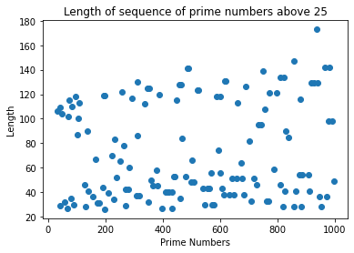

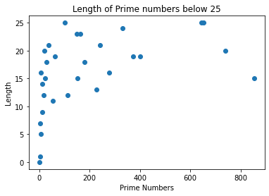

```python
#holds the length of prime num above 25
primeAbove25 = []
#holds number associated with primeAbove25
primenumb = []
#holds length of prime num below 25
primeBelow25 = []
#holds associated num with primeBelow25
primenumb2 = []
#loop through all the prime numbers
for i in range (len(primelen)):
    #if the length of the sequence is greater than 25 add it to its respected list
    if(primelen[i] > 25):
        primeAbove25.append(primelen[i])
        primenumb.append(prime[i])
    else:
        #else if the length of the sequqnce is below 25, add it to its respected list
        primeBelow25.append(primelen[i])
        primenumb2.append(prime[i])

plt.title("Length of sequence of prime numbers above 25")
plt.plot(primenumb, primeAbove25,'o')
plt.xlabel("Prime Numbers")
plt.ylabel("Length")
plt.show()

plt.title("Length of Prime numbers below 25")
plt.plot(primenumb2, primeBelow25,'o')
plt.xlabel("Prime Numbers")
plt.ylabel("Length")
plt.show()
```

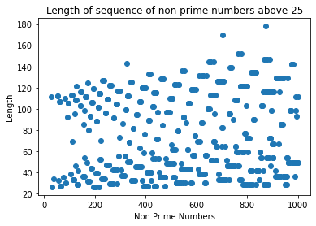

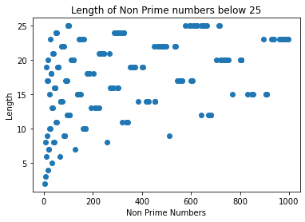

```python
#holds seq length of non prime numbers above 25
nonprimeAbove25 = []
#holds non prime num associated with nonprimeAbove25
nonprimenumb = []
#holds seq length of non prime numbers below 25
nonprimeBelow25 = []
#holds non prime num associated with nonprimeBelow25
nonprimenumb2 = []
#loop through all the non prime numbers
for i in range (len(nonprimelength)):
    #check if length is above 25, if so add it to the respective list
    if(nonprimelength[i] > 25):
        nonprimeAbove25.append(nonprimelength[i])
        nonprimenumb.append(nonprime[i])
    else:
        #else if it is less than 25 add it to its respective list
        nonprimeBelow25.append(nonprimelength[i])
        nonprimenumb2.append(nonprime[i])

plt.title("Length of sequence of non prime numbers above 25")
plt.plot(nonprimenumb, nonprimeAbove25,'o')
plt.xlabel("Non Prime Numbers")
plt.ylabel("Length")
plt.show()

plt.title("Length of Non Prime numbers below 25")
plt.plot(nonprimenumb2, nonprimeBelow25,'o')
plt.xlabel("Non Prime Numbers")
plt.ylabel("Length")
plt.show()
```

# Observation 5

I found that prime and non prime numbers tend to have similar lengths in sequences. In the above charts, both prime and non prime numbers sequence lengths reached 175 which seams to be the peak from full_sequence 0-1000. Looking at the grapth, since there is more non prime numbers, there is more dots but other than that there isn't much of a difference between prime and non prime numbers.

# Conclusion

$\text{Find a pattern where the length of the sequence increases by 1:}$

While exploring the numbers that will lead a sequence length to increase by one consistantly, I found that if the number is a power of 2, it will increase the length of the sequence by one. Ie 2,4,8,16 will all lead the sequence to increase its length by one. Another thing I noticed from this is that the sequence contained is [$a^{sequencelength-1}...1$]

$\text{Find a pattern in the first element in the sequence of even and odd numbers:}$

What I noticed while working with the first element of the even numbers is that it is all in sequential order. The first element of 2 is 1, 4 is 2, 6 is 3. As the even number goes up sequentially, so does its respective first element of the sequence since is halfed whenever it is even.